# Reading and writing files - hands-on exercise

Author

Josemari Feliciano

## Guidance

This exercise will give you hands-on experience with pivoting or reshaping data between long and wide formats.

This exercise will also give you additional dplyr and ggplot practice for the upcoming midterm.

## Load packages and data you will need

Within the script below, load the following packages we will use today:

```r
library(tidyverse)
population <- read_csv("https://raw.githubusercontent.com/jmtfeliciano/teachingdata/refs/heads/main/population_data.csv")
head(population)
```

```
# A tibble: 6 × 3
  country     year  population
  <chr>       <chr>      <dbl>
1 Afghanistan Y1995   17586073
2 Afghanistan Y1996   18415307
3 Afghanistan Y1997   19021226
4 Afghanistan Y1998   19496836
5 Afghanistan Y1999   19987071
6 Afghanistan Y2000   20595360
```

## population: Background information

The **population** data you loaded have three variables: country, year, population.

> country contains the country name,

> year corresponds to the year data was captured (from 1995 to 2013) with a ‘Y’ prefix. For example, 1995 is “Y1995” within the data.

> population is the estimated population according to the World Health Organization

## Task 1:

Note: The wide format you generate below should look partially like the table below:

| country | Y1995 | Y1996 | … |
| --- | --- | --- | --- |
| Afghanistan | 17586073 | 18415307 | … |
| Albania | 3357858 | 3341043 | … |
| … | … | … | … |

Use pivot_wider() below to transform the **population** data into wide format via the R code chunk provided below. Also save the data into your R environment (name it however you want) then print a sample of that data using head() or glimpse() within the same R code chunk.

```r
# Place your code below:
population_wider <- population |>
  pivot_wider(names_from = year,
              values_from = population)

head(population_wider)
```

```
# A tibble: 6 × 20
  country   Y1995  Y1996  Y1997  Y1998  Y1999  Y2000  Y2001  Y2002  Y2003  Y2004
  <chr>     <dbl>  <dbl>  <dbl>  <dbl>  <dbl>  <dbl>  <dbl>  <dbl>  <dbl>  <dbl>
1 Afghani… 1.76e7 1.84e7 1.90e7 1.95e7 2.00e7 2.06e7 2.13e7 2.22e7 2.31e7 2.40e7
2 Albania  3.36e6 3.34e6 3.33e6 3.33e6 3.32e6 3.30e6 3.29e6 3.26e6 3.24e6 3.22e6
3 Algeria  2.93e7 2.98e7 3.03e7 3.08e7 3.13e7 3.17e7 3.22e7 3.26e7 3.30e7 3.35e7
4 America… 5.29e4 5.39e4 5.49e4 5.59e4 5.68e4 5.75e4 5.82e4 5.87e4 5.91e4 5.93e4
5 Andorra  6.39e4 6.43e4 6.41e4 6.38e4 6.41e4 6.54e4 6.80e4 7.16e4 7.56e4 7.91e4
6 Angola   1.21e7 1.25e7 1.28e7 1.31e7 1.35e7 1.39e7 1.44e7 1.49e7 1.54e7 1.60e7
# ℹ 9 more variables: Y2005 <dbl>, Y2006 <dbl>, Y2007 <dbl>, Y2008 <dbl>,
#   Y2009 <dbl>, Y2010 <dbl>, Y2011 <dbl>, Y2012 <dbl>, Y2013 <dbl>
```

## Task 2:

Within the R chunk below, do the following: using the data you saved from Task 1, keep three variables only: country, Y1995, Y2013. Afterwards, create a variable called population_change by using the formula below: Y2013 - Y1995. Afterwards, keep the data rows if and only if the population_change is negative. Save the resulting data into your R env’t as **countries_shrunk**

```r
# Place your code below:
countries_shrunk <- population_wider |>
  select(country, Y1995, Y2013) |>
  mutate(population_change = Y2013 - Y1995) |>
  filter(population_change < 0)

head(countries_shrunk)
```

```
# A tibble: 6 × 4
  country     Y1995   Y2013 population_change
  <chr>       <dbl>   <dbl>             <dbl>
1 Albania   3357858 3173271           -184587
2 Armenia   3223173 2976566           -246607
3 Belarus  10189075 9356678           -832397
4 Bulgaria  8358116 7222943          -1135173
5 Croatia   4690192 4289714           -400478
6 Estonia   1433076 1287251           -145825
```

## Task 3:

Using **countries_shrunk** and one of more of the dplyr verbs you learned in class, identify the top five countries with the highest population drop. Write your R code below but make sure to fill in the table provided below with your answers:

```r
# Place your code below:
countries_shrunk |>
  arrange(population_change) |>
  select(-Y1995)
```

```
# A tibble: 24 × 3
   country                 Y2013 population_change
   <chr>                   <dbl>             <dbl>
 1 Ukraine              45238805          -5908162
 2 Russian Federation  142833689          -5768458
 3 Romania              21698585          -1264927
 4 Bulgaria              7222943          -1135173
 5 Republic of Moldova   3487204           -851877
 6 Belarus               9356678           -832397
 7 Georgia               4340895           -726248
 8 Lithuania             3016933           -611146
 9 Latvia                2050317           -437671
10 Germany              82726626           -421144
# ℹ 14 more rows
```

```r
# optional but smaller subject: this is technically enough but you can only print a smaller rows if desired
# you can pipe into head() or top_n()
# countries_shrunk |>
#   arrange(population_change) |>
#   select(-Y1995) |>
#   head(5)
```

| Top 5 Country With Highest Net Population Loss | Population in 2013 | Population Change from 1995 |
| --- | --- | --- |
| Ukraine |  |  |
| Russian Federation |  |  |
| Romania |  |  |
| Bulgaria |  |  |
| Republic of Moldova |  |  |

## Heart Rate Data and Background

Run the following script to load patient_heart_rate into the R environment:

```r
patient_heart_rate <- read_csv("https://raw.githubusercontent.com/jmtfeliciano/teachingdata/refs/heads/main/patient_heart_rate.csv")
head(patient_heart_rate, 10)
```

```
# A tibble: 10 × 3
   patient_id drug1 drug2
   <chr>      <dbl> <dbl>
 1 AJ9101        91    80
 2 JU9301       110    94
 3 OI1261       101    78
 4 MO0910        94    68
 5 YQ8191        98    91
 6 BD1190        95    71
 7 PL0101        91    72
 8 JD7781        99    69
 9 KL1910       105    72
10 PU9912        95    67
```

The patient_heart_rate data contains three variables: patient_id, drug1, and drug2

> patient_id are patient IDs within their electronic health records

> drug1 is the patient heart rate during doctor visit after taking drug 1 for 6 months

> drug2 is the patient heart rate during doctor visit after taking drug 2 for 6 months

The data was collected to assess the effectiveness of two drugs to control heart rates.

## Task 4:

Note: The long format you generate below should look partially like this table below:

| patient_id | drug_taken | heart_rate |
| --- | --- | --- |
| AJ9101 | drug1 | 91 |
| AJ9101 | drug2 | 80 |
| JU9301 | drug1 | 110 |
| … | … | … |

Use pivot_longer() below to transform the patient_heart_rate data into long format via the R code chunk provided below. Also save the data into your R environment (name it however you want) then print a sample of that data using head() or glimpse() within the same R code chunk.

```r
# Place your code below:
patient_heart_rate_longer <- patient_heart_rate |>
  pivot_longer(
    cols = drug1:drug2,
    names_to = "drug_taken", # look into the sample table I give you for hint
    values_to = "heart_rate" # look into the sample table for hint
  )

head(patient_heart_rate_longer)
```

```
# A tibble: 6 × 3
  patient_id drug_taken heart_rate
  <chr>      <chr>           <dbl>
1 AJ9101     drug1              91
2 AJ9101     drug2              80
3 JU9301     drug1             110
4 JU9301     drug2              94
5 OI1261     drug1             101
6 OI1261     drug2              78
```

## Task 5:

Using data you generated in task 4, generate a box plot where x is drug taken and y is heart rate.

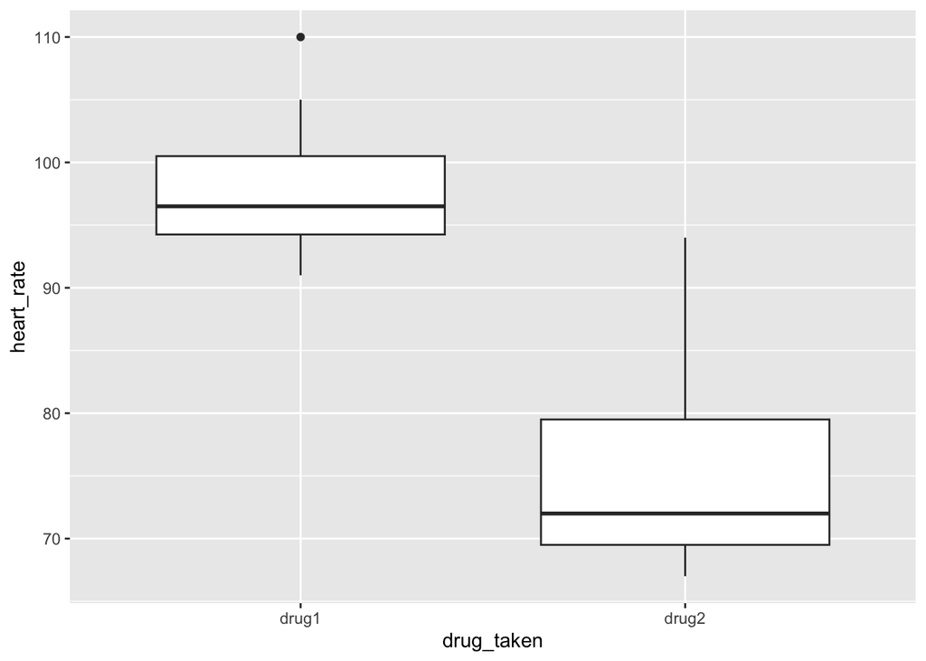

```r
# Place your code below:
ggplot(patient_heart_rate_longer,
       aes(x = drug_taken, y = heart_rate)) +
  geom_boxplot()
```

## Task 6:

The patient_heart_rate data was collected to assess the effectiveness of two drugs to control heart rates. Based on the visualization you created in Task 5, do you believe that a *preliminary* suggestive evidence exists to suggest that one drug is better in controlling heart rates? If so, which drug is better? (Hint and you may not see this hint in the exam: Focus on comparing the *approximate* value of the median. Also consider where Q1 and Q3 resides between the two drugs, which spans the middle 50% of the data.)

**Your response:**

Median heart rate under drug 1 is 97 vs 72 in drug 2. Suggestive that drug2 is better also based on the spread of the middle 50% of the observation vs drug1. More test is needed to formally confirm.

## Task 7:

Using the data you generated in Task 4, compute the *exact* median heart rate after drug 1 and drug 2 intakes using one or more dplyr verbs:

```r
# Place your code below:
patient_heart_rate_longer |>
  group_by(drug_taken) |>
  summarise(median_hr = median(heart_rate, na.rm = TRUE))
```

```
# A tibble: 2 × 2
  drug_taken median_hr
  <chr>          <dbl>
1 drug1           96.5
2 drug2           72
```

## **Extra Material**

To those with statistics background, ggstatsplot is an excellent tool for plotting box plots and it does the relevant statistical test for you.

You are not allowed you use this for your homework and exam in this course. But you are free to use it for your final project.

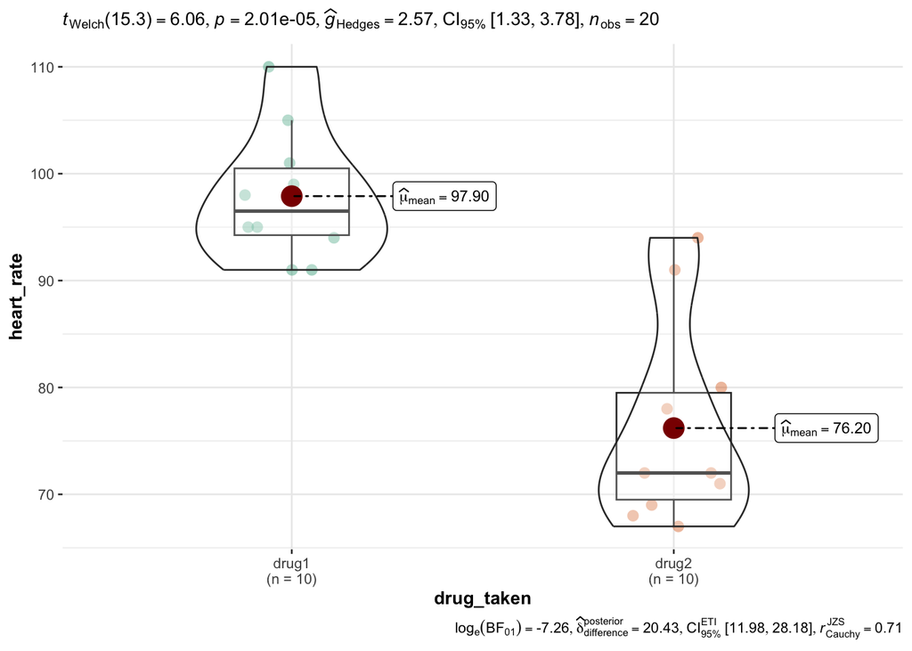

```r
# if you haven't installed, run: install.packages("ggstatsplot")
library(ggstatsplot)
ggbetweenstats(data = patient_heart_rate_longer, x = drug_taken, y = heart_rate)
```

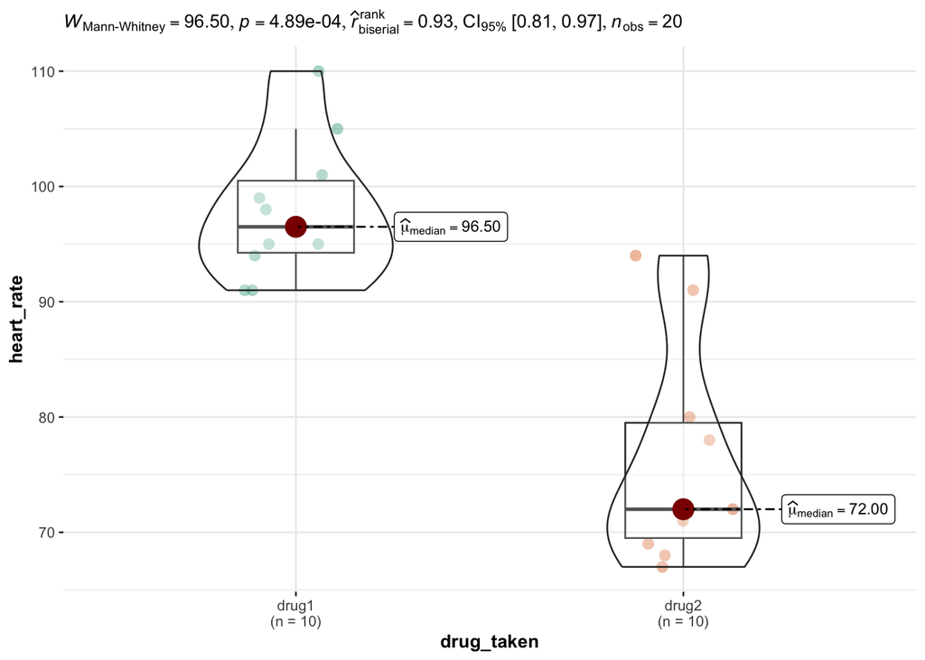

```r
ggbetweenstats(data = patient_heart_rate_longer, x = drug_taken, y = heart_rate, type = "nonparametric")
```